# Отток клиентов

Из «Бета-Банка» стали уходить клиенты. Каждый месяц. Немного, но заметно. Банковские маркетологи посчитали: сохранять текущих клиентов дешевле, чем привлекать новых.

Нужно спрогнозировать, уйдёт клиент из банка в ближайшее время или нет. Вам предоставлены исторические данные о поведении клиентов и расторжении договоров с банком.

Постройте модель с предельно большим значением *F1*-меры. Чтобы сдать проект успешно, нужно довести метрику до 0.59. Проверьте *F1*-меру на тестовой выборке самостоятельно.

Дополнительно измеряйте *AUC-ROC*, сравнивайте её значение с *F1*-мерой.

Источник данных: https://www.kaggle.com/barelydedicated/bank-customer-churn-modeling

## Подготовка данных

```python
# для библиотек

import pandas as pd
import matplotlib.pyplot as plt

from sklearn.tree import DecisionTreeClassifier
from sklearn.ensemble import RandomForestClassifier
from sklearn.linear_model import LogisticRegression

from sklearn.linear_model import LinearRegression
from sklearn.metrics import mean_absolute_error

from sklearn.model_selection import train_test_split
from sklearn.preprocessing import StandardScaler
from sklearn.metrics import f1_score
from sklearn.metrics import accuracy_score
from sklearn.metrics import recall_score
from sklearn.metrics import precision_score

from sklearn.metrics import confusion_matrix
from sklearn.metrics import roc_auc_score
from sklearn.metrics import roc_curve

from sklearn.metrics import plot_confusion_matrix
from sklearn.utils import shuffle
```

```python
# посмотрим данные

data = pd.read_csv('/datasets/Churn.csv')

data.info()
```

```
<class 'pandas.core.frame.DataFrame'>
RangeIndex: 10000 entries, 0 to 9999
Data columns (total 14 columns):
 #   Column           Non-Null Count  Dtype
---  ------           --------------  -----
 0   RowNumber        10000 non-null  int64
 1   CustomerId       10000 non-null  int64
 2   Surname          10000 non-null  object
 3   CreditScore      10000 non-null  int64
 4   Geography        10000 non-null  object
 5   Gender           10000 non-null  object
 6   Age              10000 non-null  int64
 7   Tenure           9091 non-null   float64
 8   Balance          10000 non-null  float64
 9   NumOfProducts    10000 non-null  int64
 10  HasCrCard        10000 non-null  int64
 11  IsActiveMember   10000 non-null  int64
 12  EstimatedSalary  10000 non-null  float64
 13  Exited           10000 non-null  int64
dtypes: float64(3), int64(8), object(3)
memory usage: 1.1+ MB
```

```python
data.head()
```

|  | RowNumber | CustomerId | Surname | CreditScore | Geography | Gender | Age | Tenure | Balance | NumOfProducts | HasCrCard | IsActiveMember | EstimatedSalary | Exited |
| --- | --- | --- | --- | --- | --- | --- | --- | --- | --- | --- | --- | --- | --- | --- |
| 0 | 1 | 15634602 | Hargrave | 619 | France | Female | 42 | 2.0 | 0.00 | 1 | 1 | 1 | 101348.88 | 1 |
| 1 | 2 | 15647311 | Hill | 608 | Spain | Female | 41 | 1.0 | 83807.86 | 1 | 0 | 1 | 112542.58 | 0 |
| 2 | 3 | 15619304 | Onio | 502 | France | Female | 42 | 8.0 | 159660.80 | 3 | 1 | 0 | 113931.57 | 1 |
| 3 | 4 | 15701354 | Boni | 699 | France | Female | 39 | 1.0 | 0.00 | 2 | 0 | 0 | 93826.63 | 0 |
| 4 | 5 | 15737888 | Mitchell | 850 | Spain | Female | 43 | 2.0 | 125510.82 | 1 | 1 | 1 | 79084.10 | 0 |

Для удобства ориентирования укажем значения наименования столбцов.

- RowNumber — индекс строки в данных
- CustomerId — уникальный идентификатор клиента
- Surname — фамилия
- CreditScore — кредитный рейтинг
- Geography — страна проживания
- Gender — пол
- Age — возраст
- Tenure — сколько лет человек является клиентом банка
- Balance — баланс на счёте
- NumOfProducts — количество продуктов банка, используемых клиентом
- HasCrCard — наличие кредитной карты
- IsActiveMember — активность клиента
- EstimatedSalary — предполагаемая зарплата
- Exited — факт ухода клиента

```python
# приведем к нижнему регистру наименование столбцов и столбцы Geography, Gender и Surname

data.columns = data.columns.str.lower()
data['geography'] = data['geography'].str.lower()
data['gender'] = data['gender'].str.lower()
data['surname'] = data['surname'].str.lower()

data.head()
```

|  | rownumber | customerid | surname | creditscore | geography | gender | age | tenure | balance | numofproducts | hascrcard | isactivemember | estimatedsalary | exited |
| --- | --- | --- | --- | --- | --- | --- | --- | --- | --- | --- | --- | --- | --- | --- |
| 0 | 1 | 15634602 | hargrave | 619 | france | female | 42 | 2.0 | 0.00 | 1 | 1 | 1 | 101348.88 | 1 |
| 1 | 2 | 15647311 | hill | 608 | spain | female | 41 | 1.0 | 83807.86 | 1 | 0 | 1 | 112542.58 | 0 |
| 2 | 3 | 15619304 | onio | 502 | france | female | 42 | 8.0 | 159660.80 | 3 | 1 | 0 | 113931.57 | 1 |
| 3 | 4 | 15701354 | boni | 699 | france | female | 39 | 1.0 | 0.00 | 2 | 0 | 0 | 93826.63 | 0 |
| 4 | 5 | 15737888 | mitchell | 850 | spain | female | 43 | 2.0 | 125510.82 | 1 | 1 | 1 | 79084.10 | 0 |

Уберем столбцы rownumber, customerid и surname как не нужные для исследований.

```python
drop_array = ['rownumber', 'customerid', 'surname']

df = data.drop(drop_array, axis=1)

df.head()
```

|  | creditscore | geography | gender | age | tenure | balance | numofproducts | hascrcard | isactivemember | estimatedsalary | exited |
| --- | --- | --- | --- | --- | --- | --- | --- | --- | --- | --- | --- |
| 0 | 619 | france | female | 42 | 2.0 | 0.00 | 1 | 1 | 1 | 101348.88 | 1 |
| 1 | 608 | spain | female | 41 | 1.0 | 83807.86 | 1 | 0 | 1 | 112542.58 | 0 |
| 2 | 502 | france | female | 42 | 8.0 | 159660.80 | 3 | 1 | 0 | 113931.57 | 1 |
| 3 | 699 | france | female | 39 | 1.0 | 0.00 | 2 | 0 | 0 | 93826.63 | 0 |
| 4 | 850 | spain | female | 43 | 2.0 | 125510.82 | 1 | 1 | 1 | 79084.10 | 0 |

```python
# узнаем число пропусков

df.isna().sum()
```

```
creditscore          0
geography            0
gender               0
age                  0
tenure             909
balance              0
numofproducts        0
hascrcard            0
isactivemember       0
estimatedsalary      0
exited               0
dtype: int64
```

Пропуски только в столбце tenure - сколько лет клиент является клиентом банка. Количество пропусков составляет порядка 10% от базы. Это не мало.

Пропуск этих значений может быть технической ошибкой, тк год начала обслуживания пользователя обычно информация, которая заполняется автоматически при открытии счета. Проверим, заполнены ли данные по клиентам, у которых пропуски в столбце tenure.

```python
df[df['tenure'].isna()].head()
```

|  | creditscore | geography | gender | age | tenure | balance | numofproducts | hascrcard | isactivemember | estimatedsalary | exited |
| --- | --- | --- | --- | --- | --- | --- | --- | --- | --- | --- | --- |
| 30 | 591 | spain | female | 39 | NaN | 0.00 | 3 | 1 | 0 | 140469.38 | 1 |
| 48 | 550 | germany | male | 38 | NaN | 103391.38 | 1 | 0 | 1 | 90878.13 | 0 |
| 51 | 585 | germany | male | 36 | NaN | 146050.97 | 2 | 0 | 0 | 86424.57 | 0 |
| 53 | 655 | germany | male | 41 | NaN | 125561.97 | 1 | 0 | 0 | 164040.94 | 1 |
| 60 | 742 | germany | male | 35 | NaN | 136857.00 | 1 | 0 | 0 | 84509.57 | 0 |

Данные о пользователях есть. Построим график по столбцу tenure, чтобы лучше понять, чем заполнен столбец.

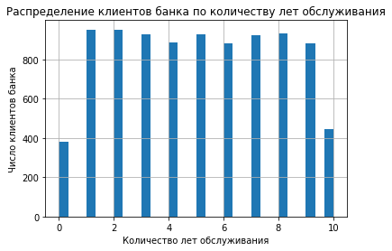

```python
df['tenure'].hist(bins = 30)

plt.title('Распределение клиентов банка по количеству лет обслуживания')
plt.xlabel("Количество лет обслуживания")
plt.ylabel("Число клиентов банка")
```

Исходя из данных, заполним пропуски столбца tenure средним значением.

```python
df['tenure'] = df['tenure'].fillna(df['tenure'].mean())

df.info()
```

```
<class 'pandas.core.frame.DataFrame'>
RangeIndex: 10000 entries, 0 to 9999
Data columns (total 11 columns):
 #   Column           Non-Null Count  Dtype
---  ------           --------------  -----
 0   creditscore      10000 non-null  int64
 1   geography        10000 non-null  object
 2   gender           10000 non-null  object
 3   age              10000 non-null  int64
 4   tenure           10000 non-null  float64
 5   balance          10000 non-null  float64
 6   numofproducts    10000 non-null  int64
 7   hascrcard        10000 non-null  int64
 8   isactivemember   10000 non-null  int64
 9   estimatedsalary  10000 non-null  float64
 10  exited           10000 non-null  int64
dtypes: float64(3), int64(6), object(2)
memory usage: 859.5+ KB
```

Проверим данные на дубликаты.

```python
df.duplicated().sum()
```

```
0
```

Дубликатов нет.

Вывод пункта 1:

- Нам дан датафрейм в 10 000 строк и 14 столбцов
- Пропуски есть только в столбце tenure в количестве 909 строк
- Дубликатов нет

Было сделано:

- Приведены названия столбцов и их содержимого к нижнему регистру
- Удалены стоблцы 'rownumber'- номер строки, 'customerid' - id клиента, 'surname' - фамилия клиента, как не важные для дальнейших исследований
- Заполнены пропуски в столбце tenure - общий срок обслуживания клиента в банке - средним значением по столбцу.
- Получена на выходе база с 10 000 строк и 11 столбцов

## Исследование задачи

Целевой признак, для предсказания которого мы будем строить модель - exited — факт ухода клиента.

Для начала посмотрим какую долю составляет положительный (равный 1) целевой признак в наших данных.

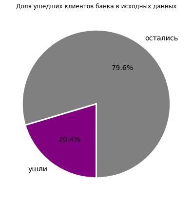

```python
sizes = df['exited'].value_counts(sort = True)
colors = ["grey","purple"]
fig, axes = plt.subplots(1, figsize = (7,7))
labels= ['остались', 'ушли']

plt.pie(sizes,
        colors=colors,
        autopct='%1.1f%%',
        startangle=270,
        wedgeprops={'linewidth': 3.0, 'edgecolor': 'white'},
        textprops={'size': 'x-large'},
        labels = labels,
        )

plt.title('Доля ушедших клиентов банка в исходных данных')
plt.show()
```

Наблюдаем дисбаланс классов. Для начала построим модели при дисбалансе классов.

### Подготовка данных для обучения модели

Для дальнейшего исследования необходимо подготовить данные для обучения модели. Перевести категоривальные данные в числовые, произвести масштабирование и разбить данные на тестову, валидационную и обучающие выборки.

Два столбца наших данных имеют тип object. Проверим уникальные значения столбцов geography и gender.

```python
print(df['gender'].value_counts())

print(df['geography'].value_counts())
```

```
male      5457
female    4543
Name: gender, dtype: int64
france     5014
germany    2509
spain      2477
Name: geography, dtype: int64
```

Для обучения модели нам необходимо перевести данные в этих столбцах в цифровые значения. Воспользуемся One-Hot Encoding, тк этот метод кодирования данных подходит для всех моделей. Чтобы избежать мультиколлинеарности новых столбцов, ставим drop_first=True.

```python
df_dum = pd.get_dummies(df, drop_first=True, columns=['gender', 'geography'])

df_dum.head()
```

|  | creditscore | age | tenure | balance | numofproducts | hascrcard | isactivemember | estimatedsalary | exited | gender_male | geography_germany | geography_spain |
| --- | --- | --- | --- | --- | --- | --- | --- | --- | --- | --- | --- | --- |
| 0 | 619 | 42 | 2.0 | 0.00 | 1 | 1 | 1 | 101348.88 | 1 | 0 | 0 | 0 |
| 1 | 608 | 41 | 1.0 | 83807.86 | 1 | 0 | 1 | 112542.58 | 0 | 0 | 0 | 1 |
| 2 | 502 | 42 | 8.0 | 159660.80 | 3 | 1 | 0 | 113931.57 | 1 | 0 | 0 | 0 |
| 3 | 699 | 39 | 1.0 | 0.00 | 2 | 0 | 0 | 93826.63 | 0 | 0 | 0 | 0 |
| 4 | 850 | 43 | 2.0 | 125510.82 | 1 | 1 | 1 | 79084.10 | 0 | 0 | 0 | 1 |

```python
# узнаем размер полученного датафрейма

df_dum.info()
```

```
<class 'pandas.core.frame.DataFrame'>
RangeIndex: 10000 entries, 0 to 9999
Data columns (total 12 columns):
 #   Column             Non-Null Count  Dtype
---  ------             --------------  -----
 0   creditscore        10000 non-null  int64
 1   age                10000 non-null  int64
 2   tenure             10000 non-null  float64
 3   balance            10000 non-null  float64
 4   numofproducts      10000 non-null  int64
 5   hascrcard          10000 non-null  int64
 6   isactivemember     10000 non-null  int64
 7   estimatedsalary    10000 non-null  float64
 8   exited             10000 non-null  int64
 9   gender_male        10000 non-null  uint8
 10  geography_germany  10000 non-null  uint8
 11  geography_spain    10000 non-null  uint8
dtypes: float64(3), int64(6), uint8(3)
memory usage: 732.5 KB
```

Разделим данные на обучающую и валидационную выборки . Произведем маштабирование данных.

```python
target = df_dum['exited']
features = df_dum.drop('exited', axis=1)
features_train, features_x, target_train, target_x = train_test_split(
    features, target, test_size=0.4, random_state=12345)

features_valid, features_test,  target_valid, target_test = train_test_split(
    features_x, target_x, test_size=0.5, random_state=12345)
```

```python
# проверим выборки на размерность

print('features:', features.shape)
print('target:', target.shape)

print('features_train:', features_train.shape)
print('target_train:', target_train.shape)

print('features_valid:', features_valid.shape)
print('target_valid:', target_valid.shape)

print('features_test:', features_test.shape)
print('target_test:', target_test.shape)
```

```
features: (10000, 11)
target: (10000,)
features_train: (6000, 11)
target_train: (6000,)
features_valid: (2000, 11)
target_valid: (2000,)
features_test: (2000, 11)
target_test: (2000,)
```

```python
# столбцы, данные в которых необходимо масштабировать

numeric = ['creditscore', 'age', 'tenure', 'balance', 'numofproducts', 'estimatedsalary']

scaler = StandardScaler()
scaler.fit(features_train[numeric])
pd.options.mode.chained_assignment = None

features_train[numeric] = scaler.transform(features_train[numeric])

features_valid[numeric]= scaler.transform(features_valid[numeric])

features_test[numeric]= scaler.transform(features_test[numeric])

print('features_train:', features_train.shape)
print('features_valid:', features_valid.shape)
print('features_test:', features_test.shape)
```

```
features_train: (6000, 11)
features_valid: (2000, 11)
features_test: (2000, 11)
```

```python
features_train.head()
```

|  | creditscore | age | tenure | balance | numofproducts | hascrcard | isactivemember | estimatedsalary | gender_male | geography_germany | geography_spain |
| --- | --- | --- | --- | --- | --- | --- | --- | --- | --- | --- | --- |
| 7479 | -0.886751 | -0.373192 | 1.082354 | 1.232271 | -0.891560 | 1 | 0 | -0.187705 | 1 | 0 | 1 |
| 3411 | 0.608663 | -0.183385 | 1.082354 | 0.600563 | -0.891560 | 0 | 0 | -0.333945 | 0 | 0 | 0 |
| 6027 | 2.052152 | 0.480939 | -0.737618 | 1.027098 | 0.830152 | 0 | 1 | 1.503095 | 1 | 1 | 0 |
| 1247 | -1.457915 | -1.417129 | 0.354365 | -1.233163 | 0.830152 | 1 | 0 | -1.071061 | 1 | 0 | 0 |
| 3716 | 0.130961 | -1.132419 | -1.101612 | 1.140475 | -0.891560 | 0 | 0 | 1.524268 | 0 | 1 | 0 |

```python
features_valid.head()
```

|  | creditscore | age | tenure | balance | numofproducts | hascrcard | isactivemember | estimatedsalary | gender_male | geography_germany | geography_spain |
| --- | --- | --- | --- | --- | --- | --- | --- | --- | --- | --- | --- |
| 8532 | -0.699824 | -0.373192 | -1.101612 | -1.233163 | 0.830152 | 1 | 0 | -0.015173 | 0 | 0 | 0 |
| 5799 | -0.284431 | 0.575842 | -0.737618 | -1.233163 | -0.891560 | 1 | 1 | 1.471724 | 0 | 0 | 0 |
| 5511 | 0.151731 | -0.657902 | -1.829601 | 0.438711 | -0.891560 | 1 | 0 | -1.367107 | 1 | 1 | 0 |
| 7365 | -0.876366 | -0.278288 | 1.810342 | 1.239884 | -0.891560 | 1 | 1 | -0.786517 | 0 | 0 | 1 |
| 7367 | -0.481743 | 0.291132 | 1.810342 | -1.233163 | 0.830152 | 1 | 0 | 1.358533 | 1 | 0 | 1 |

```python
features_test.head()
```

|  | creditscore | age | tenure | balance | numofproducts | hascrcard | isactivemember | estimatedsalary | gender_male | geography_germany | geography_spain |
| --- | --- | --- | --- | --- | --- | --- | --- | --- | --- | --- | --- |
| 7041 | -2.226392 | -0.088482 | -1.101612 | -1.233163 | 0.830152 | 1 | 0 | 0.647083 | 1 | 0 | 0 |
| 5709 | -0.087120 | 0.006422 | 1.446348 | -1.233163 | -0.891560 | 1 | 0 | -1.658410 | 0 | 0 | 0 |
| 7117 | -0.917905 | -0.752805 | -0.009629 | 0.722307 | -0.891560 | 1 | 1 | -1.369334 | 1 | 0 | 1 |
| 7775 | -0.253277 | 0.101325 | 1.810342 | -1.233163 | 0.830152 | 1 | 0 | 0.075086 | 1 | 0 | 1 |
| 8735 | 0.785204 | -0.847708 | 1.810342 | 0.615625 | -0.891560 | 0 | 1 | -1.070919 | 1 | 0 | 0 |

### Построение модели при дисбалансе классов

Построим модели при дисбалансе классов. Выберем лучший вариант из моделей при различный параметрах, ориентируясь на F1-меру, согласно заданию.

#### Дерево решений

```python
best_model = None
best_f1 = 0

for depth in range(1, 10):
    model_tree = DecisionTreeClassifier(random_state=12345,
                                        max_depth=depth)

    model_tree.fit(features_train, target_train)
    predictions_valid_tree = model_tree.predict(features_valid)
    f1_tree = f1_score(target_valid, predictions_valid_tree)

    if f1_tree > best_f1:
        best_model = model_tree
        best_depth = depth
        best_f1 = f1_tree

print('Оптимальная глубина дерева:', best_depth)
print('F1 модели:', f1_tree)
```

```
Оптимальная глубина дерева: 6
F1 модели: 0.5650349650349651
```

```python
# обучим модель с оптимальными значениями гиперпараметров, посчитаем F1, Accuracy и AUC-ROC модели

model_tree = DecisionTreeClassifier(random_state=12345,
                                    max_depth=6)

model_tree.fit(features_train, target_train)
predictions_valid_tree = model_tree.predict(features_valid)

print("Accuracy:", accuracy_score(target_valid, predictions_valid_tree))
print("F1:", f1_score(target_valid, predictions_valid_tree))

probabilities_valid_tree = model_tree.predict_proba(features_valid)
probabilities_one_valid_tree = probabilities_valid_tree[:, 1]

auc_roc_tree = roc_auc_score(target_valid, probabilities_one_valid_tree)

print('AUC-ROC:', auc_roc_tree)
```

```
Accuracy: 0.858
F1: 0.5696969696969697
AUC-ROC: 0.8164631712023421
```

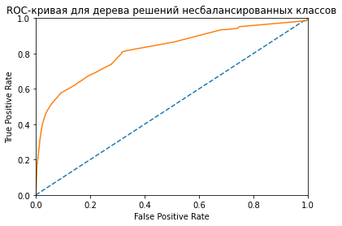

```python
# построим график

fpr, tpr, thresholds = roc_curve(target_valid, probabilities_one_valid_tree)

plt.figure()
plt.plot([0, 1], [0, 1], linestyle='--')
plt.plot(fpr, tpr)
plt.xlim([0.0, 1.0])
plt.ylim([0.0, 1.0])
plt.xlabel('False Positive Rate')
plt.ylabel('True Positive Rate')
plt.title('ROC-кривая для дерева решений несбалансированных классов')
```

#### Случайный лес

```python
# найдем оптимальное число деревьев для модели случайного леса для метрики F1

best_model = None

for est in range(10, 101, 10):
    for depth in range(1, 10):
        model_forest = RandomForestClassifier(random_state=12345,
                                              n_estimators=est,
                                              max_depth=depth)
        model_forest.fit(features_train, target_train)
        predictions_valid_forest = model_forest.predict(features_valid)
        f1_forest = f1_score(target_valid, predictions_valid_forest)
        if f1_forest > best_f1:
            best_model = model_forest
            best_est = est
            best_depth = depth

print('Оптимальное число деревьев:', best_est)
print('Оптимальная глубина дерева:', best_depth)
print('F1 модели:', f1_forest)
```

```
Оптимальное число деревьев: 100
Оптимальная глубина дерева: 9
F1 модели: 0.5741029641185648
```

```python
# обучим модель с оптимальными значениями гиперпараметров,  F1, Accuracy и AUC-ROC модели

model_forest = RandomForestClassifier(random_state=12345,
                                              n_estimators=100,
                                              max_depth=9)

model_forest.fit(features_train, target_train)
predictions_valid_forest = model_forest.predict(features_valid)

print("Accuracy:", accuracy_score(target_valid, predictions_valid_forest))
print("F1:", f1_score(target_valid, predictions_valid_forest))

probabilities_valid_forest = model_forest.predict_proba(features_valid)
probabilities_one_valid_forest = probabilities_valid_forest[:, 1]

auc_roc_forest = roc_auc_score(target_valid, probabilities_one_valid_forest)

print('AUC-ROC',auc_roc_forest)
```

```
Accuracy: 0.8635
F1: 0.5741029641185648
AUC-ROC 0.8513994156751493
```

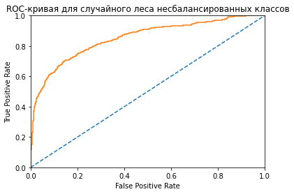

```python
# построим график

fpr, tpr, thresholds = roc_curve(target_valid, probabilities_one_valid_forest)

plt.figure()
plt.plot([0, 1], [0, 1], linestyle='--')
plt.plot(fpr, tpr)
plt.xlim([0.0, 1.0])
plt.ylim([0.0, 1.0])
plt.xlabel('False Positive Rate')
plt.ylabel('True Positive Rate')
plt.title('ROC-кривая для случайного леса несбалансированных классов')
```

#### Логистическая регрессия

```python
model_log = LogisticRegression(random_state=12345,
                               solver='liblinear')
model_log.fit(features_train, target_train)
predictions_valid_log = model_log.predict(features_valid)

print("Accuracy:", accuracy_score(target_valid, predictions_valid_log))
print("F1:", f1_score(target_valid, predictions_valid_log))

probabilities_valid_log = model_log.predict_proba(features_valid)
probabilities_one_valid_log = probabilities_valid_log[:, 1]

auc_roc_log= roc_auc_score(target_valid, probabilities_one_valid_log)

print('AUC-ROC:', auc_roc_log)
```

```
Accuracy: 0.802
F1: 0.33108108108108103
AUC-ROC: 0.7587497504824008
```

[figure not shown]

```python
# построим график

fpr, tpr, thresholds = roc_curve(target_valid, probabilities_one_valid_forest)

plt.figure()
plt.plot([0, 1], [0, 1], linestyle='--')
plt.plot(fpr, tpr)
plt.xlim([0.0, 1.0])
plt.ylim([0.0, 1.0])
plt.xlabel('False Positive Rate')
plt.ylabel('True Positive Rate')
plt.title('ROC-кривая для логистической регрессии несбалансированных классов')
```

Сравним показатели AUC-ROC для различных моделей, что мы применили.

```python
data_auc_disbalance_dic = {'Модель': ['Tree', 'Forest', 'Logistic'], 'AUC-ROC': [auc_roc_tree, auc_roc_forest, auc_roc_log]}
data_auc_disbalance = pd.DataFrame(data_auc_disbalance_dic)

data_auc_disbalance.head()
```

|  | Модель | AUC-ROC |
| --- | --- | --- |
| 0 | Tree | 0.816463 |
| 1 | Forest | 0.851399 |
| 2 | Logistic | 0.758750 |

Сравним показатели F1 для различных моделей, что мы применили.

```python
f1_tree = f1_score(target_valid, predictions_valid_tree)
f1_forest = f1_score(target_valid, predictions_valid_forest)
f1_log = f1_score(target_valid, predictions_valid_log)

data_f1_disbalance_dic = {'Модель': ['Tree', 'Forest', 'Logistic'], 'F1': [f1_tree, f1_forest, f1_log]}
data_f1_disbalance = pd.DataFrame(data_f1_disbalance_dic)

data_f1_disbalance.head()
```

|  | Модель | F1 |
| --- | --- | --- |
| 0 | Tree | 0.569697 |
| 1 | Forest | 0.574103 |
| 2 | Logistic | 0.331081 |

Получили наилучший показатель F1 у модели случайного леса. Показатель AUC-ROC оказался самым высоким тоже для этой модели. Проверим матрицу ошибок для всех трех моделей.

### Матрица ошибок

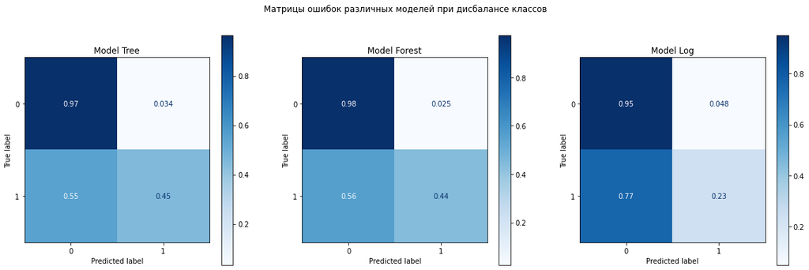

```python
fig, ax = plt.subplots(1, 3, figsize = (20,6))
fig.suptitle('Матрицы ошибок различных моделей при дисбалансе классов')



#fig, ax = plot_confusion_matrix(conf_mat=binary1)
#plt.show()

plot_confusion_matrix(estimator=model_tree,
                      X=features_valid,
                      y_true=target_valid,
                      normalize='true',
                      cmap='Blues',
                      ax = ax[0])

ax[0].set_title("Model Tree")

plot_confusion_matrix(estimator=model_forest,
                      X=features_valid,
                      y_true=target_valid,
                      normalize='true',
                      cmap='Blues',
                      ax = ax[1])

ax[1].set_title("Model Forest")

plot_confusion_matrix(estimator=model_log,
                      X=features_valid,
                      y_true=target_valid,
                      normalize='true',
                      cmap='Blues',
                      ax = ax[2])

ax[2].set_title("Model Log")

plt.show()
```

Матрицы ошибок для разных моделей при дисбалансе классов показывают в среднем одинаково хорошие показатели оставшихся клиентов - 95-97% точности, при этом показатель ушедших клиентов предсказывают плохо. Хуже всего Логистическая регрессия - 23%, лучше всего Дерево решений - 45%.

Вывод шага 2:

- Категориальные данные столбцов были переведены в числовые методом One-Hot Encoding
- Подготовленные данные были масштабированы по столбцам 'creditscore', 'age', 'tenure', 'balance', 'numofproducts', 'estimatedsalary'
- Данные были разделены на тестовую, валидационную и обучающую выборки в соотношении 60/20/20
- У целевого признака наблюдается дисбаланс классов в пользу значения 0 (оставшиеся клиенты)
- Построили модели Дерево решений, Случайный лес и Логистическая регрессия при дисбалансе классов с оптимальными показателями для метрики F1
- Получили лучший показатель F1 для модели Случайный лес - 0.57
- Построили матрицы ошибок для всех трех моделей - они показывают, что все три модели хорошо предсказывают доминирующий класс, но точность предсказания класса 1 (уход из банка) не превышает точности 45%

## Борьба с дисбалансом

Теперь сбалансируем данные. У нас для этого есть три способа:

- Взвешивание классов
- Увеличение выборки
- Уменьшение выборки

Для каждого способа построим модели Дерево решений, Случайный лес и Логистическая регрессия и проверим показатели параметра метрики F1 и посмотрим на значение AUC-ROC. Выведем матрицы ошибок.

### Взвешивание классов

#### Логистическая регрессия

```python
# посчитаем метрики для модели  Логистической регрессии при взвешивании классов

model_log_bw = LogisticRegression(random_state=12345,
                               solver='liblinear',
                               class_weight='balanced')

model_log_bw.fit(features_train, target_train)
predictions_valid_log = model_log_bw.predict(features_valid)

print("F1:", f1_score(target_valid, predictions_valid_log))

probabilities_valid = model_log_bw.predict_proba(features_valid)
probabilities_one_valid = probabilities_valid[:, 1]

print("AUC-ROC:", roc_auc_score(target_valid, probabilities_one_valid))
```

```
F1: 0.4888507718696398
AUC-ROC: 0.7637295168734386
```

```python
# создадим датафрейм, чтобы потом сравнить все значения F1 для всех моделей и методом балансировки классов. Будем заполнять его
# по мере подсчета значений

f1_log_bw = f1_score(target_valid, predictions_valid_log)

data_f1_balance_dic = {'Модель F1': ['Tree', 'Forest', 'Logistic'], 'Без баланса': [f1_tree, f1_forest, f1_log],
                       'Взвешивание': [0,0,f1_log_bw],
                      'Увеличение':[0.,0.,0.], 'Уменьшение': [0.,0.,0.]}

data_f1_balance = pd.DataFrame(data_f1_balance_dic)

data_f1_balance.head()
```

|  | Модель F1 | Без баланса | Взвешивание | Увеличение | Уменьшение |
| --- | --- | --- | --- | --- | --- |
| 0 | Tree | 0.569697 | 0.000000 | 0.0 | 0.0 |
| 1 | Forest | 0.574103 | 0.000000 | 0.0 | 0.0 |
| 2 | Logistic | 0.331081 | 0.488851 | 0.0 | 0.0 |

```python
# создадим аналогичный датафрейм, чтобы потом сравнить все значения AUC-ROC для всех моделей и методом балансировки классов.
# Будем заполнять его по мере подсчета значений

auc_log_bw = roc_auc_score(target_valid, probabilities_one_valid)

data_auc_balance_dic = {'Модель AUC': ['Tree', 'Forest', 'Logistic'], 'Без баланса': [auc_roc_tree, auc_roc_forest, auc_roc_log],
                       'Взвешивание': [0,0, auc_log_bw],
                      'Увеличение':[0.,0.,0.], 'Уменьшение': [0.,0.,0.]}

data_auc_balance = pd.DataFrame(data_auc_balance_dic)

data_auc_balance.head()
```

|  | Модель AUC | Без баланса | Взвешивание | Увеличение | Уменьшение |
| --- | --- | --- | --- | --- | --- |
| 0 | Tree | 0.816463 | 0.00000 | 0.0 | 0.0 |
| 1 | Forest | 0.851399 | 0.00000 | 0.0 | 0.0 |
| 2 | Logistic | 0.758750 | 0.76373 | 0.0 | 0.0 |

#### Дерево решений

```python
# подберем лучшие гиперпараметры при взвешивании классов

best_model = None
best_f1 = 0

for depth in range(1, 10):
    model_tree_bw = DecisionTreeClassifier(random_state=12345,
                                        max_depth=depth,
                                        class_weight='balanced')
    model_tree_bw.fit(features_train, target_train)
    predictions_valid_tree = model_tree_bw.predict(features_valid)
    f1_tree_bw = f1_score(target_valid, predictions_valid_tree)
    if f1_tree_bw > best_f1:
        best_model = model_tree_bw
        best_depth = depth
        best_f1 = f1_tree_bw

print('Оптимальная глубина дерева:', best_depth)
print('F1', f1_tree_bw)
```

```
Оптимальная глубина дерева: 5
F1 0.532555879494655
```

```python
# обучаем модель с оптимальными значениями гиперпараметров при взвешивании классов

model_tree_bw = DecisionTreeClassifier(random_state=12345,
                                    max_depth=5,
                                    class_weight='balanced')

model_tree_bw.fit(features_train, target_train)
predictions_valid_tree = model_tree_bw.predict(features_valid)

print("F1:", f1_score(target_valid, predictions_valid_tree))

probabilities_valid = model_tree_bw.predict_proba(features_valid)
probabilities_one_valid = probabilities_valid[:, 1]

print("AUC-ROC:", roc_auc_score(target_valid, probabilities_one_valid))
```

```
F1: 0.5963791267305644
AUC-ROC: 0.8310244134068074
```

```python
# внесем данные в таблицы

data_f1_balance['Взвешивание'][0] = f1_score(target_valid, predictions_valid_tree)

data_f1_balance.head()
```

|  | Модель F1 | Без баланса | Взвешивание | Увеличение | Уменьшение |
| --- | --- | --- | --- | --- | --- |
| 0 | Tree | 0.569697 | 0.596379 | 0.0 | 0.0 |
| 1 | Forest | 0.574103 | 0.000000 | 0.0 | 0.0 |
| 2 | Logistic | 0.331081 | 0.488851 | 0.0 | 0.0 |

```python
data_auc_balance['Взвешивание'][0] = roc_auc_score(target_valid, probabilities_one_valid)

data_auc_balance.head()
```

|  | Модель AUC | Без баланса | Взвешивание | Увеличение | Уменьшение |
| --- | --- | --- | --- | --- | --- |
| 0 | Tree | 0.816463 | 0.831024 | 0.0 | 0.0 |
| 1 | Forest | 0.851399 | 0.000000 | 0.0 | 0.0 |
| 2 | Logistic | 0.758750 | 0.763730 | 0.0 | 0.0 |

#### Случайный лес

```python
# подберем лучшие гиперпараметры для модели Случайный лес при взвешивании классов

best_model = None
for est in range(10, 101, 10):
    for depth in range(1, 10):
        model_forest_bw = RandomForestClassifier(random_state=12345,
                                              n_estimators=est,
                                              max_depth=depth,
                                              class_weight='balanced')
        model_forest_bw.fit(features_train, target_train)
        predictions_valid_forest = model_forest_bw.predict(features_valid)
        f1_forest_bw = f1_score(target_valid, predictions_valid_forest)
        if f1_forest_bw > best_f1:
            best_model = model_forest_bw
            best_est = est
            best_depth = depth

print('Оптимальное количество деревьев:', best_est)
print('Оптимальная глубина дерева:', best_depth)
```

```
Оптимальное количество деревьев: 100
Оптимальная глубина дерева: 9
```

```python
# обучим модель с оптимальными значениями гиперпараметров

model_forest_bw = RandomForestClassifier(random_state=12345,
                                      n_estimators=100,
                                      max_depth=9,
                                      class_weight='balanced')

model_forest_bw.fit(features_train, target_train)
predictions_valid_forest = model_forest_bw.predict(features_valid)


print("F1:", f1_score(target_valid, predictions_valid_forest))

probabilities_valid = model_forest_bw.predict_proba(features_valid)
probabilities_one_valid = probabilities_valid[:, 1]

print("AUC-ROC:", roc_auc_score(target_valid, probabilities_one_valid))
```

```
F1: 0.6280417149478563
AUC-ROC: 0.8521948475371857
```

```python
# внесем данные в таблицу

data_f1_balance['Взвешивание'][1] = f1_score(target_valid, predictions_valid_forest)

data_f1_balance.head()
```

|  | Модель F1 | Без баланса | Взвешивание | Увеличение | Уменьшение |
| --- | --- | --- | --- | --- | --- |
| 0 | Tree | 0.569697 | 0.596379 | 0.0 | 0.0 |
| 1 | Forest | 0.574103 | 0.628042 | 0.0 | 0.0 |
| 2 | Logistic | 0.331081 | 0.488851 | 0.0 | 0.0 |

```python
data_auc_balance['Взвешивание'][1] = roc_auc_score(target_valid, probabilities_one_valid)

data_auc_balance.head()
```

|  | Модель AUC | Без баланса | Взвешивание | Увеличение | Уменьшение |
| --- | --- | --- | --- | --- | --- |
| 0 | Tree | 0.816463 | 0.831024 | 0.0 | 0.0 |
| 1 | Forest | 0.851399 | 0.852195 | 0.0 | 0.0 |
| 2 | Logistic | 0.758750 | 0.763730 | 0.0 | 0.0 |

### Увеличение выборки

Введем функцию для увеличения выборки несбалансированных классов. Тк соотношение у нас примерно 80 % к 20%, значит меньшую выборку необходимо увеличить в 4 раза. Данные перемешать.

```python
def upsample(features, target, repeat):
    features_zeros = features[target == 0]
    features_ones = features[target == 1]
    target_zeros = target[target == 0]
    target_ones = target[target == 1]

    features_upsampled = pd.concat([features_zeros] + [features_ones] * repeat)
    target_upsampled = pd.concat([target_zeros] + [target_ones] * repeat)

    features_upsampled, target_upsampled = shuffle(
        features_upsampled, target_upsampled, random_state=12345)

    return features_upsampled, target_upsampled

features_upsampled, target_upsampled = upsample(features_train, target_train, 4)

print(features_upsampled.shape)
print(target_upsampled.shape)
```

```
(9588, 11)
(9588,)
```

#### Логистическая регрессия

```python
# найдем значение метрик для модели Логистической регресси при увеличении выборки

model_log_up = LogisticRegression(random_state=12345,
                               solver='liblinear')

model_log_up.fit(features_upsampled, target_upsampled)
predictions_valid_log = model_log_up.predict(features_valid)

print("F1:", f1_score(target_valid, predictions_valid_log))

probabilities_valid = model_log_up.predict_proba(features_valid)
probabilities_one_valid = probabilities_valid[:, 1]

print("AUC-ROC:", roc_auc_score(target_valid, probabilities_one_valid))
```

```
F1: 0.4888507718696398
AUC-ROC: 0.7636478565682107
```

```python
# внесем данные в таблицу

data_f1_balance['Увеличение'][2] = f1_score(target_valid, predictions_valid_log)

data_f1_balance.head()
```

|  | Модель F1 | Без баланса | Взвешивание | Увеличение | Уменьшение |
| --- | --- | --- | --- | --- | --- |
| 0 | Tree | 0.569697 | 0.596379 | 0.000000 | 0.0 |
| 1 | Forest | 0.574103 | 0.628042 | 0.000000 | 0.0 |
| 2 | Logistic | 0.331081 | 0.488851 | 0.488851 | 0.0 |

```python
data_auc_balance['Увеличение'][2] = roc_auc_score(target_valid, probabilities_one_valid)

data_auc_balance.head()
```

|  | Модель AUC | Без баланса | Взвешивание | Увеличение | Уменьшение |
| --- | --- | --- | --- | --- | --- |
| 0 | Tree | 0.816463 | 0.831024 | 0.000000 | 0.0 |
| 1 | Forest | 0.851399 | 0.852195 | 0.000000 | 0.0 |
| 2 | Logistic | 0.758750 | 0.763730 | 0.763648 | 0.0 |

#### Дерево решений

```python
# подберем лучшие гиперпараметры для модели Дерево решений при увеличении выборки

best_model = None
best_f1 = 0

for depth in range(1, 10):
    model_tree_up = DecisionTreeClassifier(random_state=12345,
                                        max_depth=depth)

    model_tree_up.fit(features_upsampled, target_upsampled)
    predictions_valid_tree = model_tree_up.predict(features_valid)
    f1_tree_up = f1_score(target_valid, predictions_valid_tree)
    if f1_tree_up > best_f1:
        best_model = model_tree_up
        best_depth = depth
        best_f1 = f1_tree_up

print('Оптимальная глубина дерева:', best_depth)
print('F1:', f1_tree_up)
```

```
Оптимальная глубина дерева: 5
F1: 0.5315227934044616
```

```python
# обучим модель с оптимальными параметрами

model_tree_up = DecisionTreeClassifier(random_state=12345,
                                    max_depth=5)

model_tree_up.fit(features_upsampled, target_upsampled)
predictions_valid_tree = model_tree.predict(features_valid)

print("F1:", f1_score(target_valid, predictions_valid_tree))

probabilities_valid = model_tree_up.predict_proba(features_valid)
probabilities_one_valid = probabilities_valid[:, 1]

print("AUC-ROC", roc_auc_score(target_valid, probabilities_one_valid))
```

```
F1: 0.5696969696969697
AUC-ROC 0.8310244134068074
```

```python
# внесем данные в таблицу

data_f1_balance['Увеличение'][0] = f1_score(target_valid, predictions_valid_tree)

data_f1_balance.head()
```

|  | Модель F1 | Без баланса | Взвешивание | Увеличение | Уменьшение |
| --- | --- | --- | --- | --- | --- |
| 0 | Tree | 0.569697 | 0.596379 | 0.569697 | 0.0 |
| 1 | Forest | 0.574103 | 0.628042 | 0.000000 | 0.0 |
| 2 | Logistic | 0.331081 | 0.488851 | 0.488851 | 0.0 |

```python
data_auc_balance['Увеличение'][0] = roc_auc_score(target_valid, probabilities_one_valid)

data_auc_balance.head()
```

|  | Модель AUC | Без баланса | Взвешивание | Увеличение | Уменьшение |
| --- | --- | --- | --- | --- | --- |
| 0 | Tree | 0.816463 | 0.831024 | 0.831024 | 0.0 |
| 1 | Forest | 0.851399 | 0.852195 | 0.000000 | 0.0 |
| 2 | Logistic | 0.758750 | 0.763730 | 0.763648 | 0.0 |

#### Случайный лес

```python
# подберем лучшие гиперпараметры для модели Случайный лес при увеличении выборки

best_model = None

for est in range(10, 101, 10):
    for depth in range(1, 10):
        model_forest_up = RandomForestClassifier(random_state=12345,
                                              n_estimators=est,
                                              max_depth=depth)

        model_forest_up.fit(features_upsampled, target_upsampled)
        predictions_valid_forest = model_forest_up.predict(features_valid)
        f1_forest_up = f1_score(target_valid, predictions_valid_forest)

        if f1_forest_up > best_f1:
            best_model = model_forest_up
            best_est = est
            best_depth = depth

print('Оптимальное количество деревьев:', best_est)
print('Оптимальная глубина дерева:', best_depth)
```

```
Оптимальное количество деревьев: 100
Оптимальная глубина дерева: 9
```

```python
# обучим модель при оптимальных параметрах

model_forest_up = RandomForestClassifier(random_state=12345,
                                      n_estimators=100,
                                      max_depth=9)

model_forest_up.fit(features_upsampled, target_upsampled)
predictions_valid_forest = model_forest_up.predict(features_valid)

print("F1:", f1_score(target_valid, predictions_valid_forest))

probabilities_valid = model_forest_up.predict_proba(features_valid)
probabilities_one_valid = probabilities_valid[:, 1]

print("AUC-ROC:", roc_auc_score(target_valid, probabilities_one_valid))
```

```
F1: 0.6142401700318809
AUC-ROC: 0.85303564623546
```

```python
# внесем данные в таблицу

data_f1_balance['Увеличение'][1] = f1_score(target_valid, predictions_valid_forest)

data_f1_balance.head()
```

|  | Модель F1 | Без баланса | Взвешивание | Увеличение | Уменьшение |
| --- | --- | --- | --- | --- | --- |
| 0 | Tree | 0.569697 | 0.596379 | 0.569697 | 0.0 |
| 1 | Forest | 0.574103 | 0.628042 | 0.614240 | 0.0 |
| 2 | Logistic | 0.331081 | 0.488851 | 0.488851 | 0.0 |

```python
data_auc_balance['Увеличение'][1] = roc_auc_score(target_valid, probabilities_one_valid)

data_auc_balance.head()
```

|  | Модель AUC | Без баланса | Взвешивание | Увеличение | Уменьшение |
| --- | --- | --- | --- | --- | --- |
| 0 | Tree | 0.816463 | 0.831024 | 0.831024 | 0.0 |
| 1 | Forest | 0.851399 | 0.852195 | 0.853036 | 0.0 |
| 2 | Logistic | 0.758750 | 0.763730 | 0.763648 | 0.0 |

### Уменьшение выборки

Применим метод уменьшения выборки. Соотношение классов у нас отличается в 4 раза. Значит будем уменьшать доминантную выборку в 4 раза. Введем соответствующую функцию.

```python
def downsample(features, target, fraction):
    features_zeros = features[target == 0]
    features_ones = features[target == 1]
    target_zeros = target[target == 0]
    target_ones = target[target == 1]


    features_downsampled = pd.concat([features_zeros.sample(frac=fraction, random_state=12345)] +
                                     [features_ones])
    target_downsampled = pd.concat([target_zeros.sample(frac=fraction, random_state=12345)] +
                                   [target_ones])

    features_downsampled, target_downsampled = shuffle(
        features_downsampled, target_downsampled, random_state=12345)

    return features_downsampled, target_downsampled

features_downsampled, target_downsampled = downsample(features_train, target_train, 0.25)

print(features_downsampled.shape)
print(target_downsampled.shape)
```

```
(2397, 11)
(2397,)
```

#### Логистическая регрессия

```python
model_log_dw = LogisticRegression(random_state=12345,
                               solver='liblinear')

model_log_dw.fit(features_downsampled, target_downsampled)
predictions_valid_log = model_log_dw.predict(features_valid)

print("F1:", f1_score(target_valid, predictions_valid_log))

probabilities_valid = model_log_dw.predict_proba(features_valid)
probabilities_one_valid = probabilities_valid[:, 1]

print("AUC-ROC:", roc_auc_score(target_valid, probabilities_one_valid))
```

```
F1: 0.48406546080964685
AUC-ROC: 0.7622883637089505
```

```python
# внесем данные в таблицу

data_f1_balance['Уменьшение'][2] = f1_score(target_valid, predictions_valid_log)

data_f1_balance.head()
```

|  | Модель F1 | Без баланса | Взвешивание | Увеличение | Уменьшение |
| --- | --- | --- | --- | --- | --- |
| 0 | Tree | 0.569697 | 0.596379 | 0.569697 | 0.000000 |
| 1 | Forest | 0.574103 | 0.628042 | 0.614240 | 0.000000 |
| 2 | Logistic | 0.331081 | 0.488851 | 0.488851 | 0.484065 |

```python
data_auc_balance['Уменьшение'][2] = roc_auc_score(target_valid, probabilities_one_valid)

data_auc_balance.head()
```

|  | Модель AUC | Без баланса | Взвешивание | Увеличение | Уменьшение |
| --- | --- | --- | --- | --- | --- |
| 0 | Tree | 0.816463 | 0.831024 | 0.831024 | 0.000000 |
| 1 | Forest | 0.851399 | 0.852195 | 0.853036 | 0.000000 |
| 2 | Logistic | 0.758750 | 0.763730 | 0.763648 | 0.762288 |

#### Дерево решений

```python
# подберем лучшие гиперпараметры для модели Дерево решений при уменьшении выборки

best_model = None
best_f1 = 0

for depth in range(1, 10):
    model_tree_dw = DecisionTreeClassifier(random_state=12345,
                                        max_depth=depth)
    model_tree_dw.fit(features_downsampled, target_downsampled)
    predictions_valid_tree = model_tree_dw.predict(features_valid)

    f1_tree_dw = f1_score(target_valid, predictions_valid_tree)
    if f1_tree_dw > best_f1:
        best_model = model_tree_dw
        best_depth = depth
        best_f1 = f1_tree_dw

print('Оптимальная глубина дерева:', best_depth)
print('F1', f1_tree_dw)
```

```
Оптимальная глубина дерева: 5
F1 0.5319926873857405
```

```python
# обучим модель с оптимальными гиперпараметрами

model_tree_dw = DecisionTreeClassifier(random_state=12345,
                                    max_depth=5)
model_tree_dw.fit(features_downsampled, target_downsampled)
predictions_valid_tree = model_tree_dw.predict(features_valid)

print("F1:", f1_score(target_valid, predictions_valid_tree))

probabilities_valid = model_tree_dw.predict_proba(features_valid)
probabilities_one_valid = probabilities_valid[:, 1]

print("AUC-ROC:", roc_auc_score(target_valid, probabilities_one_valid))
```

```
F1: 0.5953109072375127
AUC-ROC: 0.8240212861195628
```

```python
# внесем данные в таблицу

data_f1_balance['Уменьшение'][0] = f1_score(target_valid, predictions_valid_tree)

data_f1_balance.head()
```

|  | Модель F1 | Без баланса | Взвешивание | Увеличение | Уменьшение |
| --- | --- | --- | --- | --- | --- |
| 0 | Tree | 0.569697 | 0.596379 | 0.569697 | 0.595311 |
| 1 | Forest | 0.574103 | 0.628042 | 0.614240 | 0.000000 |
| 2 | Logistic | 0.331081 | 0.488851 | 0.488851 | 0.484065 |

```python
data_auc_balance['Уменьшение'][0] = roc_auc_score(target_valid, probabilities_one_valid)

data_auc_balance.head()
```

|  | Модель AUC | Без баланса | Взвешивание | Увеличение | Уменьшение |
| --- | --- | --- | --- | --- | --- |
| 0 | Tree | 0.816463 | 0.831024 | 0.831024 | 0.824021 |
| 1 | Forest | 0.851399 | 0.852195 | 0.853036 | 0.000000 |
| 2 | Logistic | 0.758750 | 0.763730 | 0.763648 | 0.762288 |

#### Случайный лес

```python
# подберем лучшие гиперпараметры для модели Случайный лес при уменьшении выборки

best_model = None
for est in range(10, 101, 10):
    for depth in range(1, 10):
        model_forest_dw = RandomForestClassifier(random_state=12345,
                                              n_estimators=est,
                                              max_depth=depth)
        model_forest_dw.fit(features_downsampled, target_downsampled)
        predictions_valid_forest = model_forest_dw.predict(features_valid)

        f1_forest_dw = f1_score(target_valid, predictions_valid_forest)
        if f1_forest_dw > best_f1:
            best_model = model_forest_dw
            best_est = est
            best_depth = depth

print('Оптимальное количество деревьев:', best_est)
print('Оптимальная глубина дерева:', best_depth)
```

```
Оптимальное количество деревьев: 100
Оптимальная глубина дерева: 8
```

```python
# обучим модель с оптимальными параметрами

model_forest_dw = RandomForestClassifier(random_state=12345,
                                      n_estimators=100,
                                      max_depth=8)
model_forest_dw.fit(features_downsampled, target_downsampled)
predictions_valid_forest = model_forest_dw.predict(features_valid)


print("F1:", f1_score(target_valid, predictions_valid_forest))

probabilities_valid = model_forest_dw.predict_proba(features_valid)
probabilities_one_valid = probabilities_valid[:, 1]

print("AUC-ROC:", roc_auc_score(target_valid, probabilities_one_valid))
```

```
F1: 0.5959885386819483
AUC-ROC: 0.8497843563050829
```

```python
# внесем данные в таблицу

data_f1_balance['Уменьшение'][1] = f1_score(target_valid, predictions_valid_forest)

data_f1_balance.head()
```

|  | Модель F1 | Без баланса | Взвешивание | Увеличение | Уменьшение |
| --- | --- | --- | --- | --- | --- |
| 0 | Tree | 0.569697 | 0.596379 | 0.569697 | 0.595311 |
| 1 | Forest | 0.574103 | 0.628042 | 0.614240 | 0.595989 |
| 2 | Logistic | 0.331081 | 0.488851 | 0.488851 | 0.484065 |

```python
data_auc_balance['Уменьшение'][1] = roc_auc_score(target_valid, probabilities_one_valid)

data_auc_balance.head()
```

|  | Модель AUC | Без баланса | Взвешивание | Увеличение | Уменьшение |
| --- | --- | --- | --- | --- | --- |
| 0 | Tree | 0.816463 | 0.831024 | 0.831024 | 0.824021 |
| 1 | Forest | 0.851399 | 0.852195 | 0.853036 | 0.849784 |
| 2 | Logistic | 0.758750 | 0.763730 | 0.763648 | 0.762288 |

### Матрица ошибок для лучшей модели

Построим матрицу ошибок для лучшей модели для метрики F1. Ею оказалась модель Случайного леса при балансировке классов методом взвешивания.

```
<sklearn.metrics._plot.confusion_matrix.ConfusionMatrixDisplay at 0x7f76bb07c3a0>
```

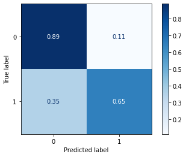

```python
plot_confusion_matrix(estimator=model_forest_bw,
                      X = features_valid,
                      y_true = target_valid,
                      normalize='true',
                      cmap='Blues')
```

Качество предсказаний модели True Negative - 89%, True Positive - 65%

## Тестирование модели

Протестируем модель на тестовой выборке. Найдем значение метрик F1 и AUC-ROC.

```python
predictions_valid_forest_final = model_forest_bw.predict(features_test)


print("F1:", f1_score(target_test, predictions_valid_forest_final))

probabilities_valid = model_forest_bw.predict_proba(features_test)
probabilities_one_valid = probabilities_valid[:, 1]

print("AUC-ROC:", roc_auc_score(target_test, probabilities_one_valid))
```

```
F1: 0.6120591581342435
AUC-ROC: 0.859968429147722
```

Значение F1= 0.612, это выше значения 0.59 по заданию.

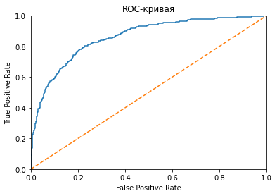

```python
# построим ROC-кривую

fpr, tpr, thresholds = roc_curve(target_test, probabilities_one_valid)

plt.figure()
plt.plot(fpr, tpr, linestyle='solid')
plt.plot([0, 1], [0, 1], linestyle='--')
plt.xlim([0.0, 1.0])
plt.ylim([0.0, 1.0])
plt.xlabel('False Positive Rate')
plt.ylabel('True Positive Rate')
plt.title('ROC-кривая')
plt.show()
```

```python
#Создаем константную модель

target_predict_constant = pd.Series([0]*len(target_test))
target_predict_constant.value_counts()
```

```
0    2000
dtype: int64
```

```python
#Сравним показатель точности accuracy_score константной модели и финальной

print('Accuracy_score константой модели:', accuracy_score(target_valid, target_predict_constant))
print('Accuracy_score финальной модели:', accuracy_score(target_test, predictions_valid_forest_final))

#Дополнительно сравним AUC-ROC — единственный параметр подающийся сравнению,
#потому что константная подель содержит только негативные ответы

print('AUC-ROC константой модели:', roc_auc_score(target_valid, target_predict_constant))
print('AUC-ROC финальной модели:', roc_auc_score(target_test, probabilities_one_valid))
```

```
Accuracy_score константой модели: 0.791
Accuracy_score финальной модели: 0.8295
AUC-ROC константой модели: 0.5
AUC-ROC финальной модели: 0.859968429147722
```

Финальная модель показывает результаты лучше, чем константная модель, значит нашу модель можно считать адекватной.

## Общий вывод

Подготовка данных:

- Нам дан датафрейм в 10 000 строк и 14 столбцов
- Пропуски есть только в столбце tenure в количестве 909 строк
- Дубликатов нет

Было сделано:

- Приведены названия столбцов и их содержимого к нижнему регистру
- Удалены стоблцы 'rownumber'- номер строки, 'customerid' - id клиента, 'surname' - фамилия клиента, как не важные для дальнейших исследований
- Заполнены пропуски в столбце tenure - общий срок обслуживания клиента в банке - средним значением по столбцу.
- Получена на выходе база с 10 000 строк и 11 столбцов

Исследование задачи:

- Категориальные данные столбцов были переведены в числовые методом One-Hot Encoding
- Подготовленные данные были масштабированы по столбцам 'creditscore', 'age', 'tenure', 'balance', 'numofproducts', 'estimatedsalary'
- Данные были разделены на тестовую, валидационную и обучающую выборки в соотношении 60/20/20
- У целевого признака наблюдается дисбаланс классов в пользу значения 0 (оставшиеся клиенты)

Построение моделей без учета дисбаланса:

- Построили модели Дерево решений, Случайный лес и Логистическая регрессия при дисбалансе классов с оптимальными показателями для метрики F1
- Получили лучший показатель F1 для модели Случайный лес - 0.57
- Построили матрицы ошибок для всех трех моделей - они показывают, что все три модели хорошо предсказывают доминирующий класс, но точность предсказания класса 1 (уход из банка) не превышает точности 45%

Тестирование модели:

- Протестировали лучшую модель на тестовой выборке
- Получили значения метрик F1: 0.6120591581342435 и AUC-ROC: 0.859968429147722
- Полученное значение F1 больше 0.59 по заданию
- Значение AUC-ROC близко к 1
- Построили график ROC - кривой
- Проверили модель на адекватность, сравнив Accuracy_score константой и финальной модели. Модель прошла тест на адекватность